# Statistical Methods for Discrete Response, Time Series, and Panel Data (W271): Lab 4

W271 Instructional Team

Fall 2018

# Instructions:

- $\textbf{Due Date: 12/11/2018 (11:59 p.m. Pacific Time)}$
- $\textbf{Page limit of the pdf report: 20 (not include title and the table of content page}$
- Use the margin, linespace, and font size specification below:
  - fontsize=11pt
  - margin=1in
  - line_spacing=single
- Submission:
  - Each group makes one submission to Github; please have one of your team members made the submission
  - Submit 2 files:
    1. A pdf file including the details of your analysis and all the R codes used to produce the analysis. Please do not suppress the codes in your pdf file.
    2. R markdown file used to produce the pdf file
  - Use the following file-naming convensation; fail to do so will receive 10% reduction in the grade:
    - FirstNameLastName1_FirstNameLastName2_FirstNameLastName3_LabNumber.fileExtension
    - For example, if you have three students in the group for Lab Z, and their names are Gerard Kelley, Steve Yang, and Jeffrey Yau, then you should name your file the following
      - GerardKelley_SteveYang_JeffreyYau_LabZ.Rmd
      - GerardKelley_SteveYang_JeffreyYau_LabZ.pdf
  - Although it sounds obvious, please write the name of each members of your group on page 1 of your pdf and Rmd files.
- This lab can be completed in a group of up to 3 students in your session. Students are encouraged to work in a group for the lab.
- For statistical methods that we cover in this course, use only the R libraries and functions that are covered in this course. If you use libraries and functions for statistical modeling that we have not covered, you have to provide (1) explanation of why such libraries and functions are used instead and (2) reference to the library documentation. Lacking the explanation and reference to the documentation will result in a score of zero for the corresponding question.
- Students are expected to act with regards to UC Berkeley Academic Integrity.

# Description of the Lab

In this lab, you are asked to answer the question **“Do changes in traffic laws affect traffic fatalities?”** To do so, you will conduct the tasks specified below using the data set *driving.Rdata*, which includes 25 years of data that cover changes in various state drunk driving, seat belt, and speed limit laws.

Specifically, this data set contains data for the 48 continental U.S. states from 1980 through 2004. Various driving laws are indicated in the data set, such as the alcohol level at which drivers are considered legally intoxicated. There are also indicators for “per se” laws—where licenses can be revoked without a trial—and seat belt laws. A few economics and demographic variables are also included. The description of the each of the variables in the dataset is come with the dataste.

**Exercises:**

1. Load the data. Provide a description of the basic structure of the dataset, as we have done throughout the semester. Conduct a very thorough EDA, which should include both graphical and tabular techniques, on the dataset, including both the dependent variable *totfatrte* and the potential explanatory variables. You need to write a detailed narrative of your observations of your EDA. *Reminder: giving an “output dump” (i.e. providing a bunch of graphs and tables without description and hoping your audience will interpret them) will receive a zero in this exercise.*
2. How is the our dependent variable of interest *totfatrte* defined? What is the average of this variable in each of the years in the time period covered in this dataset? Estimate a linear regression model of *totfatrte* on a set of dummy variables for the years 1981 through 2004. What does this model explain? Describe what you find in this model. Did driving become safer over this period? Please provide a detailed explanation.
3. Expand your model in *Exercise 2* by adding variables *bac08, bac10, perse, sbprim, sbsecon, sl70plus, gdl, perc14_24, unem, vehicmilespc*, and perhaps *transformations of some or all of these variables*. Please explain carefully your rationale, which should be based on your EDA, behind any transformation you made. If no transformation is made, explain why transformation is not needed. How are the variables *bac8* and *bac10* defined? Interpret the coefficients on *bac8* and *bac10*. Do *per se laws* have a negative effect on the fatality rate? What about having a primary seat belt law? (Note that if a law was enacted sometime within a year the fraction of the year is recorded in place of the zero-one indicator.)
4. Reestimate the model from *Exercise 3* using a fixed effects (at the state level) model. How do the coefficients on *bac08, bac10, perse, and sbprim* compare with the pooled OLS estimates? Which set of estimates do you think is more reliable? What assumptions are needed in each of these models? Are these assumptions reasonable in the current context?
5. Would you perfer to use a random effects model instead of the fixed effects model you built in *Exercise 4*? Please explain.
6. Suppose that *vehicmilespc*, the number of miles driven per capita, increases by $1,000$. Using the FE estimates, what is the estimated effect on *totfatrte*? Please interpret the estimate.
7. If there is serial correlation or heteroskedasticity in the idiosyncratic errors of the model, what would be the consequences on the estimators and their standard errors?

```r
library(dplyr)
library(ggplot2)
```

## Exploratory Panel Data Analysis

```r
load('driving.RData')
df <- data
```

How have total fatalities (`totfatrte`) changed over time?:

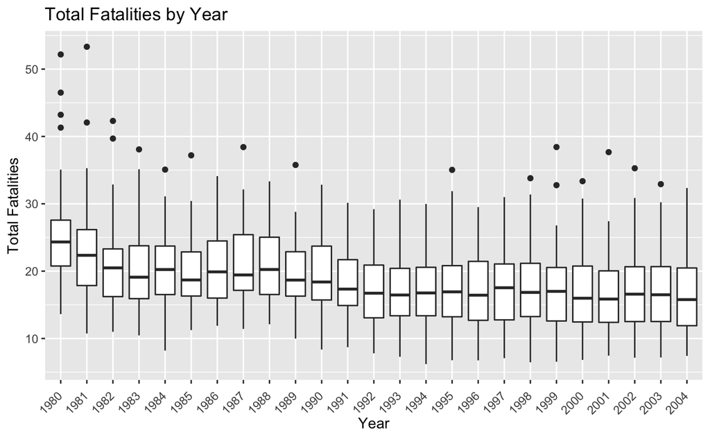

```r
ggplot(data, aes(as.factor(year), totfatrte)) +
  geom_boxplot() +
  ggtitle('Total Fatalities by Year') +
  xlab('Year') + ylab('Total Fatalities') +
  theme(axis.text.x = element_text(angle = 45, hjust = 1.2))
```

The plot shows that total fatalities trends download as the years progress.

To statistically evaluate how totfatrte changes over time, we’ll regress it against a set of dummy variables for years 1981 thru 2004:

```r
totfatrte.yrs.mod <- lm(totfatrte ~ as.factor(year), data=data)
summary(totfatrte.yrs.mod)
```

```
Call:
lm(formula = totfatrte ~ as.factor(year), data = data)

Residuals:
     Min       1Q   Median       3Q      Max
-12.9302  -4.3468  -0.7305   3.7488  29.6498

Coefficients:
                    Estimate Std. Error t value Pr(>|t|)
(Intercept)          25.4946     0.8671  29.401  < 2e-16 ***
as.factor(year)1981  -1.8244     1.2263  -1.488 0.137094
as.factor(year)1982  -4.5521     1.2263  -3.712 0.000215 ***
as.factor(year)1983  -5.3417     1.2263  -4.356 1.44e-05 ***
as.factor(year)1984  -5.2271     1.2263  -4.263 2.18e-05 ***
as.factor(year)1985  -5.6431     1.2263  -4.602 4.64e-06 ***
as.factor(year)1986  -4.6942     1.2263  -3.828 0.000136 ***
as.factor(year)1987  -4.7198     1.2263  -3.849 0.000125 ***
as.factor(year)1988  -4.6029     1.2263  -3.754 0.000183 ***
as.factor(year)1989  -5.7223     1.2263  -4.666 3.42e-06 ***
as.factor(year)1990  -5.9894     1.2263  -4.884 1.18e-06 ***
as.factor(year)1991  -7.3998     1.2263  -6.034 2.14e-09 ***
as.factor(year)1992  -8.3367     1.2263  -6.798 1.68e-11 ***
as.factor(year)1993  -8.3669     1.2263  -6.823 1.43e-11 ***
as.factor(year)1994  -8.3394     1.2263  -6.800 1.66e-11 ***
as.factor(year)1995  -7.8260     1.2263  -6.382 2.51e-10 ***
as.factor(year)1996  -8.1252     1.2263  -6.626 5.25e-11 ***
as.factor(year)1997  -7.8840     1.2263  -6.429 1.86e-10 ***
as.factor(year)1998  -8.2292     1.2263  -6.711 3.01e-11 ***
as.factor(year)1999  -8.2442     1.2263  -6.723 2.77e-11 ***
as.factor(year)2000  -8.6690     1.2263  -7.069 2.67e-12 ***
as.factor(year)2001  -8.7019     1.2263  -7.096 2.21e-12 ***
as.factor(year)2002  -8.4650     1.2263  -6.903 8.32e-12 ***
as.factor(year)2003  -8.7310     1.2263  -7.120 1.88e-12 ***
as.factor(year)2004  -8.7656     1.2263  -7.148 1.54e-12 ***
---
Signif. codes:  0 ‘***’ 0.001 ‘**’ 0.01 ‘*’ 0.05 ‘.’ 0.1 ‘ ’ 1

Residual standard error: 6.008 on 1175 degrees of freedom
Multiple R-squared:  0.1276,    Adjusted R-squared:  0.1098
F-statistic: 7.164 on 24 and 1175 DF,  p-value: < 2.2e-16
```

The summary shows that the coefficients are estimated to be negative for each year after 1980, with the coefficients being statistically significant for all years except 1981. This corroborates the observations we made in the box plot of `totfatrte` over time. Does this mean that driving became safer over this time period? The answer to that question is multi-faceted - better driving habits, more/less speeding, frequency of drunk driving, car safety.

[figure not shown]

[figure not shown]

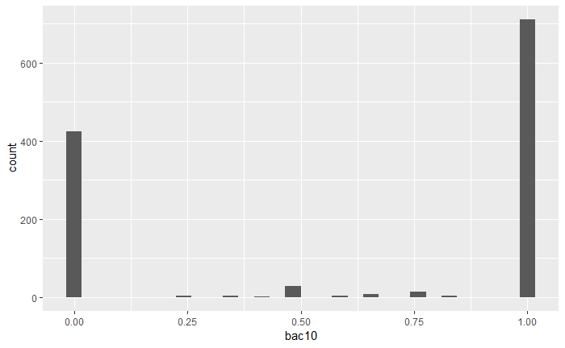

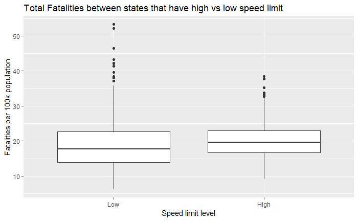